# 第三篇 R统计分析

2017-06-18

## 大纲

- **数据操作**
- **描述统计**
- **假设检验**
- **相关分析**
- **回归分析**
- **时间序列**

## 数据操作

- 数据编辑

```r
v0=rnorm(10);             # v1=edit(v0)
m0=sapply(c(2,2),runif)   # m1=edit(m0)
d0=data.frame(m0)         # d0[2,2]=0; d0$X1[1]=0;
```

- 自带数据

```r
#data()
data(sleep);tail(sleep,2)
```

```
##    extra group ID
## 19   4.6     2  9
## 20   3.4     2 10
```

## 数据操作

- 筛选

```r
v0=rnorm(10); v1=v0[v0>0.5]; v1
```

```
## [1] 0.6514399 0.7427977 0.6228837 0.6325722 1.7636487
```

```r
d0=data.frame(n=1:4,s=rep(c("aa","bb"),2),x=runif(4))
d1=d0[d0$n>2 & d0$s=="aa",]
```

- 排序

```r
v0=round(runif(n=10,min=1,max=20));               # v0[order(v0)]==sort[v0]
```

[output not shown]

## 数据操作

- 排序2

```r
d0=round(sapply(rep(5,3),runif)*20);d0=data.frame(d0);
colnames(d0)=c("x","y","z");d0
```

```
##    x  y  z
## 1 15 13  1
## 2 14 15 16
## 3  1 17 15
## 4 20  1 13
## 5  4  5  3
```

```r
ord=order(d0$x,-d0$y);      d1=d0[ord,];d1
```

```
##    x  y  z
## 3  1 17 15
## 5  4  5  3
## 2 14 15 16
## 1 15 13  1
## 4 20  1 13
```

## 数据操作

- 抽样

```r
x=1:10;sample(x,5); # replace, prob
```

```
## [1] 9 1 5 8 4
```

```r
sample(x,20,replace=TRUE,prob=rep(c(0.2,0.8),5)) #rnorm
```

```
##  [1] 6 6 1 2 4 6 6 4 4 6 4 8 1 2 4 7 8 5 2 2
```

## 概率统计-不得不说

- 概率分布

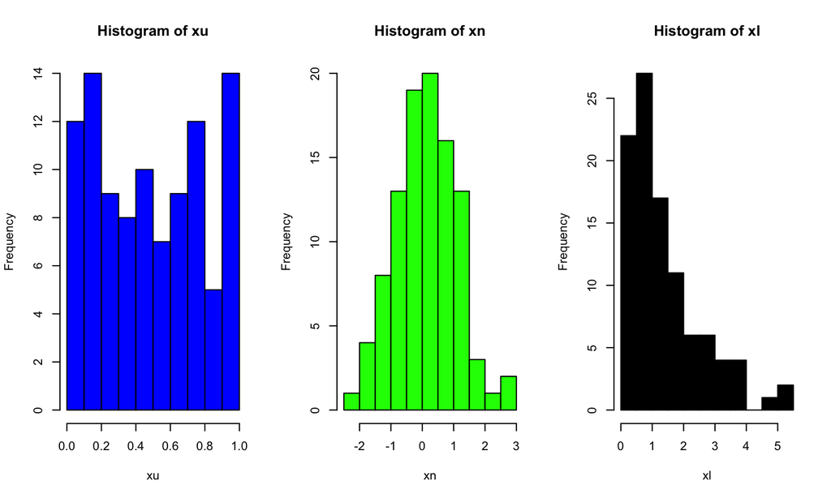

```r
# 样本空间/随机变量/概率分布
par(mfrow = c(1, 3));xu=runif(100);xn=rnorm(100);xl=rlnorm(100);
hist(xu,col='blue');hist(xn,col='green');hist(xl,col='black');
```

## 概率统计-不得不说

- 概率分布

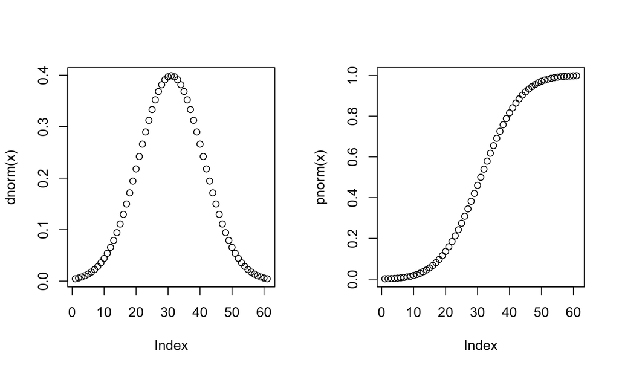

```r
# 密度函数/分布函数
par(mfrow = c(1, 2)); x=seq(-3,3,0.1);
plot(dnorm(x),type='b');plot(pnorm(x),type='b');
```

## 描述统计

- 统计量

```r
data(cars)
cars$price=round(runif(nrow(cars),min=0.8,max=10),2)
head(cars)
```

```
##   speed dist price
## 1     4    2  9.15
## 2     4   10  7.73
## 3     7    4  5.31
## 4     7   22  2.73
## 5     8   16  4.77
## 6     9   10  1.71
```

## 描述统计

- 基本统计

```r
# sum , (mean,var,sd,min,max,,median,mad),FBasics::skewness/kurtosis
sum(cars)  #vector/list/matrix/data.frame
```

```
## [1] 3162.33
```

```r
sum(cars$speed)  #vector/list/matrix/data.frame
```

```
## [1] 770
```

```r
# 行列统计
#apply(cars,1,sum)
apply(cars,2,sum)
```

```
##   speed    dist   price
##  770.00 2149.00  243.33
```

## 描述统计

- 基本统计

```r
# 非单一返回  fivenum, quantile
range(cars)
```

```
## [1]   0.83 120.00
```

```r
range(cars$speed)
```

```
## [1]  4 25
```

```r
apply(cars,2,range)
```

```
##      speed dist price
## [1,]     4    2  0.83
## [2,]    25  120  9.55
```

## 描述统计

- 分类汇总

```r
dtmp=tail(cars)
x=ave(dtmp[,2],dtmp[,1],FUN=function(x) median(x))  # factor
dtmp$distgpspeed=x; dtmp
```

```
##    speed dist price distgpspeed
## 45    23   54  2.55        54.0
## 46    24   70  7.53        92.5
## 47    24   92  4.50        92.5
## 48    24   93  4.15        92.5
## 49    24  120  4.35        92.5
## 50    25   85  2.59        85.0
```

## 描述统计

- 分类汇总

```r
dagg=aggregate(cbind(dist,price)~speed,cars,mean);head(dagg,3)
```

```
##   speed dist price
## 1     4    6  8.44
## 2     7   13  4.02
## 3     8   16  4.77
```

```r
xtabs(price~speed+dist ,head(dagg))
```

```
##      dist
## speed        6       10       13       16     22.5       26
##    4  8.440000 0.000000 0.000000 0.000000 0.000000 0.000000
##    7  0.000000 0.000000 4.020000 0.000000 0.000000 0.000000
##    8  0.000000 0.000000 0.000000 4.770000 0.000000 0.000000
##    9  0.000000 1.710000 0.000000 0.000000 0.000000 0.000000
##    10 0.000000 0.000000 0.000000 0.000000 0.000000 6.743333
##    11 0.000000 0.000000 0.000000 0.000000 5.645000 0.000000
```

## 描述统计

- 分类汇总

```r
table(tail(cars$speed))
```

```
##
## 23 24 25
##  1  4  1
```

```r
s=cars$speed;max(s);length(s)
```

```
## [1] 25
```

```
## [1] 50
```

```r
a=tabulate(s);length(a) # 小于等于0，忽略
```

```
## [1] 25
```

## 描述统计

- 茎叶图

```r
dt=cars$dist;dt[dt>=60&dt<80];stem(dt)
```

```
## [1] 60 76 68 64 66 70
```

```
##
##   The decimal point is 1 digit(s) to the right of the |
##
##    0 | 24004678
##    2 | 002466668822244466
##    4 | 002668024466
##    6 | 046806
##    8 | 04523
##   10 |
##   12 | 0
```

## 描述统计

- 基本统计量

```r
summary(cars) # r object
```

```
##      speed           dist            price
##  Min.   : 4.0   Min.   :  2.00   Min.   :0.830
##  1st Qu.:12.0   1st Qu.: 26.00   1st Qu.:2.598
##  Median :15.0   Median : 36.00   Median :4.620
##  Mean   :15.4   Mean   : 42.98   Mean   :4.867
##  3rd Qu.:19.0   3rd Qu.: 56.00   3rd Qu.:7.037
##  Max.   :25.0   Max.   :120.00   Max.   :9.550
```

## 假设检验

- 均值检验

```
##   extra group ID
## 1   0.7     1  1
```

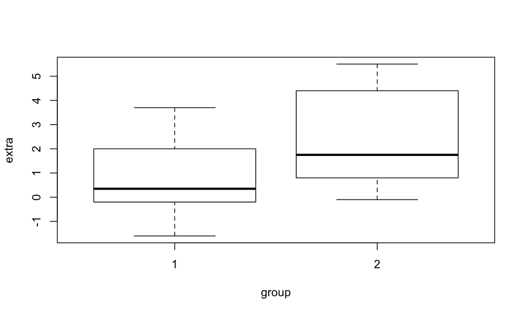

```r
data(sleep);head(sleep,1);plot(extra ~ group,sleep)#boxplot
```

## 假设检验

- 均值检验

```r
# t.test(x,y=NULL,alternative=c("two.sided","less","greater"),conf.level=0.95)
t.test(extra ~ group,data=sleep)
```

```
##
##  Welch Two Sample t-test
##
## data:  extra by group
## t = -1.8608, df = 17.776, p-value = 0.07939
## alternative hypothesis: true difference in means is not equal to 0
## 95 percent confidence interval:
##  -3.3654832  0.2054832
## sample estimates:
## mean in group 1 mean in group 2
##            0.75            2.33
```

## 假设检验

- 没有假设，就没有靠谱的检验

```r
t.test(rnorm(100),rnorm(100)+1)
```

```
##
##  Welch Two Sample t-test
##
## data:  rnorm(100) and rnorm(100) + 1
## t = -8.7449, df = 196.75, p-value = 9.928e-16
## alternative hypothesis: true difference in means is not equal to 0
## 95 percent confidence interval:
##  -1.4920969 -0.9429596
## sample estimates:
##   mean of x   mean of y
## -0.03434775  1.18318050
```

## 假设检验

- 没有假设，就没有靠谱的检验

```r
t.test(rnorm(100),c(rnorm(100)+1,1000)) # 尽然没差异了...
```

```
##
##  Welch Two Sample t-test
##
## data:  rnorm(100) and c(rnorm(100) + 1, 1000)
## t = -1.1144, df = 100.02, p-value = 0.2678
## alternative hypothesis: true difference in means is not equal to 0
## 95 percent confidence interval:
##  -30.648119   8.601821
## sample estimates:
## mean of x mean of y
## -0.090465 10.932684
```

## 假设检验

- 比例检验

```r
smokers  <- c( 83, 90, 129, 70 ) #抽烟vs肺癌
patients <- c( 86, 93, 136, 82 )
prop.test(smokers, patients)
```

```
##
##  4-sample test for equality of proportions without continuity
##  correction
##
## data:  smokers out of patients
## X-squared = 12.6, df = 3, p-value = 0.005585
## alternative hypothesis: two.sided
## sample estimates:
##    prop 1    prop 2    prop 3    prop 4
## 0.9651163 0.9677419 0.9485294 0.8536585
```

## 假设检验

- 列联表/卡方检验

```r
M;Xsq=chisq.test(M);Xsq  # Prints test summary
```

```
##       party
## gender Democrat Independent Republican
##      M      762         327        468
##      F      484         239        477
```

```
##
##  Pearson's Chi-squared test
##
## data:  M
## X-squared = 30.07, df = 2, p-value = 2.954e-07
```

## 假设检验

- 列联表/卡方检验

```r
Xsq$observed
```

```
##       party
## gender Democrat Independent Republican
##      M      762         327        468
##      F      484         239        477
```

```r
Xsq$expected
```

```
##       party
## gender Democrat Independent Republican
##      M 703.6714    319.6453   533.6834
##      F 542.3286    246.3547   411.3166
```

## 假设检验

- KS检验，样本分布是否一样

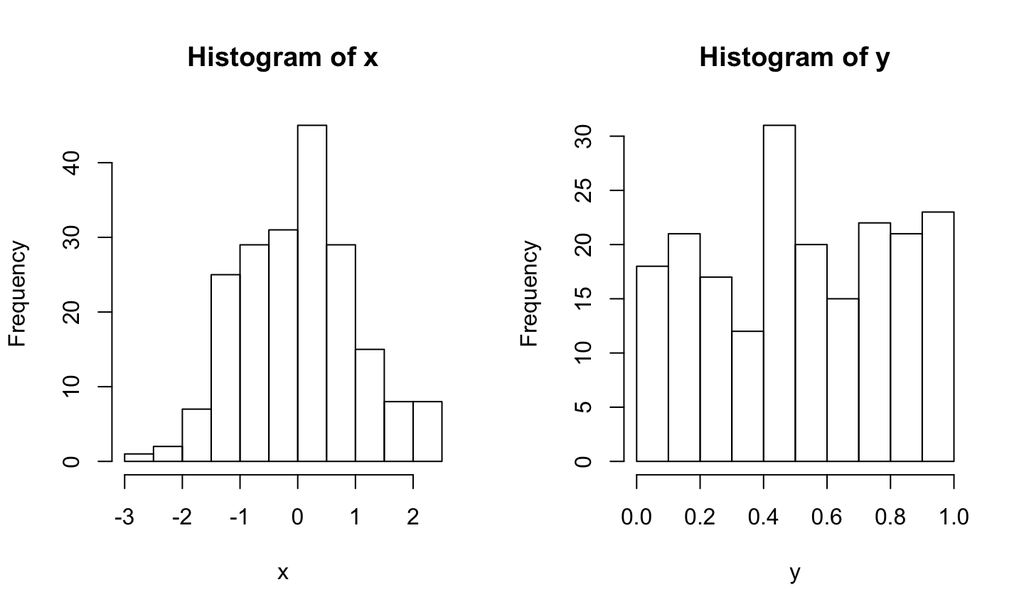

```r
x <- rnorm(200);y <- runif(200);
hist(x);hist(y);
```

## 假设检验

- KS检验，样本分布是否一样

```r
ks.test(x,y);ks.test(x,rnorm(50));  #help(anova)
```

```
##
##  Two-sample Kolmogorov-Smirnov test
##
## data:  x and y
## D = 0.475, p-value < 2.2e-16
## alternative hypothesis: two-sided
```

```
##
##  Two-sample Kolmogorov-Smirnov test
##
## data:  x and rnorm(50)
## D = 0.095, p-value = 0.8632
## alternative hypothesis: two-sided
```

## 相关分析

- 相关系数

```r
attach(cars) ; cor(dist,speed);
```

```
## [1] 0.8068949
```

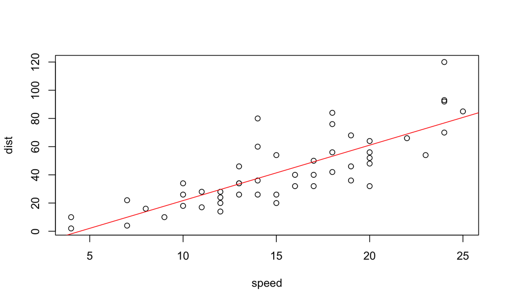

```r
plot(speed,dist); abline(m<-lm(dist~speed),col='red')
```

## 相关分析

- 相关系数的检验(零假设r=0)

```r
r=cor(dist,speed);r
```

```
## [1] 0.8068949
```

```r
cor.test(dist,speed)
```

```
##
##  Pearson's product-moment correlation
##
## data:  dist and speed
## t = 9.464, df = 48, p-value = 1.49e-12
## alternative hypothesis: true correlation is not equal to 0
## 95 percent confidence interval:
##  0.6816422 0.8862036
## sample estimates:
##       cor
## 0.8068949
```

## 相关分析

- 相关系数的检验(t统计量的计算)  
  公式：\(t=r*sqrt(n-2)/sqrt(1-r^2)\)  
  \[t=r*sqrt(n-2)/sqrt(1-r^2)\]

```r
r*sqrt(length(dist)-2)/sqrt(1-r^2)
```

```
## [1] 9.46399
```

- 其他相关  
  > cov,var,cov2cor,cor2pcor # library(corpcor)  
  > method = c("pearson", "kendall", "spearman")

## 回归分析

- 一元回归

```r
mcars=lm(dist~speed,cars);summary(mcars)
```

```
##
## Call:
## lm(formula = dist ~ speed, data = cars)
##
## Residuals:
##     Min      1Q  Median      3Q     Max
## -29.069  -9.525  -2.272   9.215  43.201
##
## Coefficients:
##             Estimate Std. Error t value Pr(>|t|)
## (Intercept) -17.5791     6.7584  -2.601   0.0123 *
## speed         3.9324     0.4155   9.464 1.49e-12 ***
## ---
## Signif. codes:  0 '***' 0.001 '**' 0.01 '*' 0.05 '.' 0.1 ' ' 1
##
## Residual standard error: 15.38 on 48 degrees of freedom
## Multiple R-squared:  0.6511, Adjusted R-squared:  0.6438
## F-statistic: 89.57 on 1 and 48 DF,  p-value: 1.49e-12
```

## 回归分析

- 一元回归,R的模型对象

```r
names(mcars);anova(mcars) #attributes
```

```
##  [1] "coefficients"  "residuals"     "effects"       "rank"
##  [5] "fitted.values" "assign"        "qr"            "df.residual"
##  [9] "xlevels"       "call"          "terms"         "model"
```

```
## Analysis of Variance Table
##
## Response: dist
##           Df Sum Sq Mean Sq F value   Pr(>F)
## speed      1  21186 21185.5  89.567 1.49e-12 ***
## Residuals 48  11354   236.5
## ---
## Signif. codes:  0 '***' 0.001 '**' 0.01 '*' 0.05 '.' 0.1 ' ' 1
```

## 回归分析

- 一元回归,置信区间

```r
pdist=predict(mcars,interval='confidence');
```

[output not shown]

## 回归分析

- 一元回归,置信区间

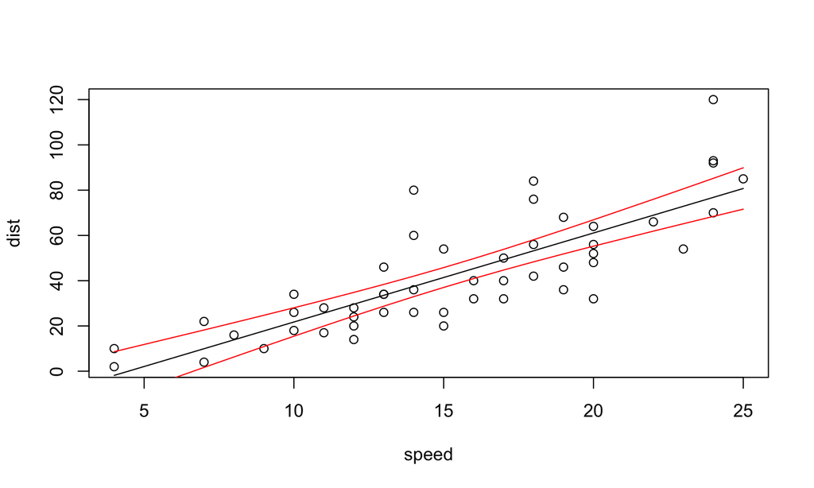

```r
plot(speed,dist);lines(speed,pdist[,1]);
lines(speed,pdist[,2],col='red');lines(speed,pdist[,3],col='red');
```

## 回归分析

- 回归诊断

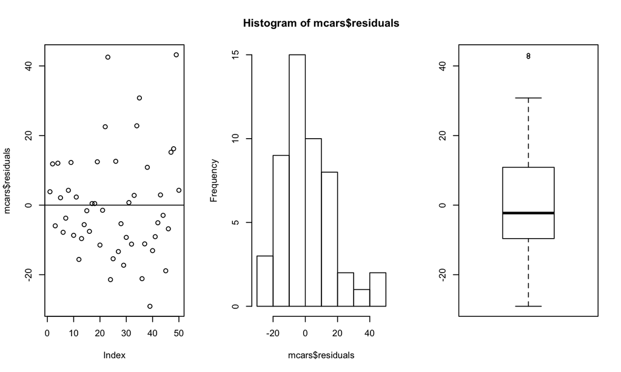

```r
plot(mcars$residuals);abline(h=0)
hist(mcars$residuals);boxplot(mcars$residuals) #qqplot
```

## 回归分析

- 线性回归，更多  
  > 多元回归  
  ** 共线性,异方差性，自相关  
  > 局部回归  
  > 广义线性回归  
  > 逻辑回归  
  > 逐步回归

## 时间序列

- 生成时间序列

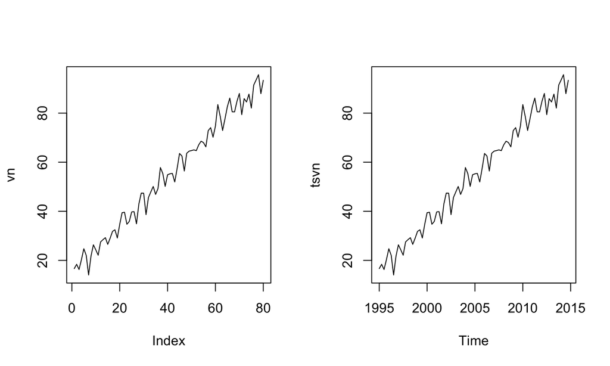

```r
vn=(11:90)+rep(c(5,4,-1,2),20)+rnorm(80,mean=2,sd=2) #runif(80,min=0,max=2)
tsvn=ts(vn,frequency=4,start=c(1995, 1))
plot(vn,type="l");plot(tsvn)
```

## 时间序列

- 序列分解

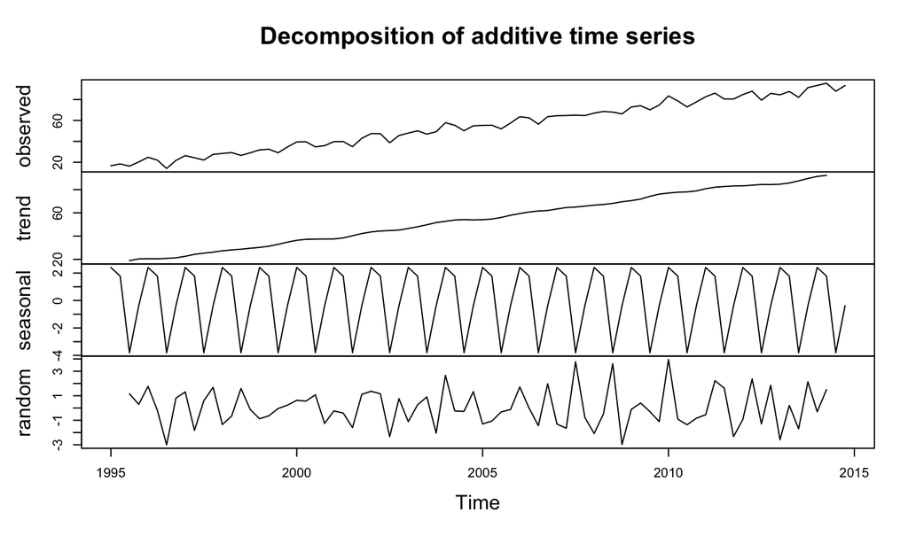

```r
dtsvn=decompose(tsvn,type="additive") #multiplicative
plot(dtsvn)
```

## 时间序列

- 序列分解

```r
attributes(dtsvn)
```

```
## $names
## [1] "x"        "seasonal" "trend"    "random"   "figure"   "type"
##
## $class
## [1] "decomposed.ts"
```

```r
dtsvn$figure
```

```
## [1]  2.4098166  1.7785182 -3.8061656 -0.3821692
```

## 时间序列

- 序列分解

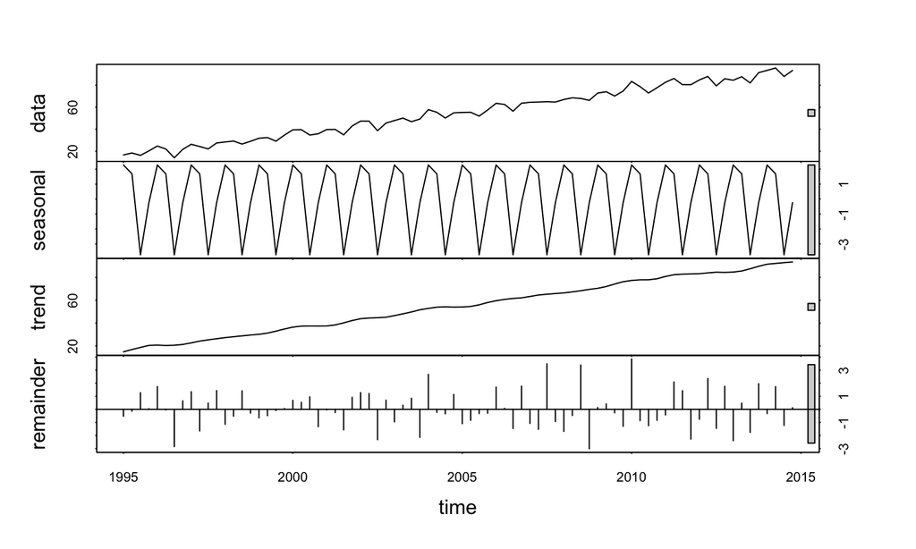

```r
# stl,  HoltWinters
d2tsvn=stl(tsvn,s.window = "periodic");plot(d2tsvn)
```

## 时间序列

- 时间序列arima  
  > 自回归  
  > 滑动平均  
  > 平稳性  
  > 差分/季节差分  
  > 定阶 #acf/pacf  
  > 残差检验

For time-series prediction, predict.ar, predict.Arima, predict.arima0, predict.HoltWinters, predict.StructTS.

## 参考

[1]: 毛岭峰,2011,"R语言基础"  
[2]: 徐俊晓,2012,"统计学与R读书笔记(第六版)"  
[3]: 薛毅,陈立萍,2006,统计建模与R软件